# Check of ‘Complex societies precede moralizing gods’ causal analysis

This document first replicates (section 1) and later extends (sections 2-4) the analyses published in the paper “Whitehouse, H., François, P., Savage, P. E., Currie, T. E., Feeney, K. C., Cioni, E., Purcell, R., Ross, R. M., Larson, J., Baines, J., ter Haar, B., Covey, A., Turchin, P. (2019). Complex societies precede moralizing gods throughout world history. Nature.”

The goal of this document is to first explain what Whitehouse et al. did, and later show that their approach was incorrect and suggest better solutions.

Note that comments in the text starting with #?? are our new comments. Also note that we are hailing from the original script, which uses a bit unfortunate approach that reuses and redefines the same variables. Hence, it may be misleading to run a specific section multiple times (it is going to overwrite results) or start from the middle of the script. As a general rule, we recommend to always run the full code that precedes the section that the reader might be interested in.

# 1. Original code

## 1.1 Load data

This section loads data on polities, their social complexity (SC), and the presence moralizing gods (MG).

```r
{
##? Load libraries
libs <- c("dplyr", "glmmTMB", "glmmADMB", "nlme", "lme4", "plotrix", "ggplot2", "stargazer", "DHARMa", "bbmle", "knitr", "car", "bootpredictlme4", "reshape", "grid", "yarrr")
lapply(libs, require, character.only = TRUE)

#library(plotrix)
#setwd("/Users/pesavage/Documents/Research/Oxford Seshat/Data/SCBigGodsOct2017")
polities <- read.csv('polities.csv', header=TRUE)

#New scripts for automated analysis of rates of change in social complexity pre/post moralising gods/doctrinal mode/writing

dat <- read.table("PC1_traj_merged.csv", sep=",", header=TRUE) #?? everything is here
dat$NGA<-as.character(dat$NGA)
NGAs <- levels(polities$NGA)
NGAs <- NGAs[NGAs != "Crete"]    #### Remove new NGAs
NGAs <- NGAs[NGAs != "Galilee"]

##? We have to include these variables for later use in the multi-level models (they will serve as nesting factors)
dat$World.Region <- as.factor(dat$World.Region)
dat$Family <- as.factor(dat$Family)
}
```

## 1.2 Pre-Post MG

Here, Whitehouse et al. first compute the earliest and latest record for each NGA, then the earliest MG date, and finally, take the mean SC at each of these timepoints. Then, they look at the difference in SC between the earliest date and MG appearence, and the latest date and MG appearence, divided by the number of centuries that differed between the earliest/latest record and MG appearence. This computation results in the difference in SC between the first/last record of NGA and the first record of NGA, corrected for the time lags between these events. This is done with 20 NGAs that have a change in MG (i.e., MG was first absent/not detected and later appeared). NGAs that don’t have variability in MG presence (MG are either present or not for all known history) are excluded.

```r
#Overall rate (beginning to end of polity)
out <- matrix(NA, nrow=0, ncol=4)
for(i in 1:length(NGAs)){
  dt <- dat[dat$NGA == NGAs[i],]
  Earliest<-subset(dt,Time==min(Time))
  Latest<-subset(dt,Time==max(Time))
  MG<-subset(dt,MoralisingGods=="1") #Replace "MoralisingGods" with "DoctrinalMode" or "Writing" to do these analyses
  MGAppear<-subset(MG, Time==min(Time))
  rates<-cbind(MGAppear$NGA,(MGAppear$Mean-Earliest$Mean)/(MGAppear$Time-Earliest$Time),
               ((Latest$Mean-MGAppear$Mean)/(Latest$Time-MGAppear$Time)),(MGAppear$End-MGAppear$Start))
  out <- rbind(out,rates)
}
colnames(out)<-c("NGA","PreRate","PostRate","MGUncertainty")
#mean(out$MGUncertainty) #Use this while replacing "MoralisingGods" as above to get uncertainty values for time-series


write.csv(out, file="FullRates.csv",  row.names=FALSE) #Exporting/importing to force it to read as numeric (there is probably a more elegant way to do this)
```

This code computes the difference between pre-MG difference in SC and post-MG difference in SC

```r
out<-read.table("FullRates.csv", sep=",", header=TRUE)

out$Difference<-out[,2]-out[,3]
write.csv(out, file="FullRates.csv",  row.names=FALSE)
```

## 1.3 Pre-Post MG by century

The analysis in section 1.2 was quite simplistic in that it didn’t control for the rate of SC change at each site. To correct for this bias, Whitehouse et al. compare mean SC at the time of the supposed MG appearance with the mean SC 100/200/300…years before/after, DIVIDED by the the time lag. Presumably, the assumption here is to weigh the differences around MG appearance more heavily in the analysis. So, if there is a sudden jump in SC 100 years before of the supposed MG appearance (edit: yes, there is, see plot 4.1.2), this approach is going to heavily skew the results toward this sudden jump.

```r
#?? We have to add World.Region and language Family to this data set, so we can use it later in the models.

#Full time windows (up to 10,000 years before and after moralizing gods)
NGAs <- levels(out$NGA)
out <- matrix(NA, nrow=0, ncol=7)
for(i in 1:length(NGAs)){
  dt <- dat[dat$NGA == NGAs[i],]
  MG<-subset(dt,MoralisingGods=="1") #Replace "MoralisingGods" with "DoctrinalMode" or "Writing" to do these analyses
  #library(dplyr)
  #MG<-as.data.frame(MG %>% group_by(PolID) %>% sample_n(size = 1)) #randomly samples so there is only one century per polity
  MGAppear<-subset(MG, Time==min(Time))
  for(j in 1: 100){
    Earliest<-subset(dt, Time==MGAppear$Time-j*100) ##? This is a confusing label, it's not earliest, this is just the number of centuries before MG
    Latest<-subset(dt, Time==MGAppear$Time+j*100) ##? This is a confusing label, it's not latest, this is just the number of centuries after MG
    rates<-cbind(MGAppear$NGA,ifelse(class(Earliest$Time)=="NULL","NA",
                                     (MGAppear$Mean-Earliest$Mean)/(MGAppear$Time-Earliest$Time)),
                 ifelse(class(Latest$Time)=="NULL","NA",((Latest$Mean-MGAppear$Mean)/(Latest$Time-MGAppear$Time))),
                 (MGAppear$End-MGAppear$Start),j*100,MGAppear$World.Region,MGAppear$Family)
    out <- rbind(out,rates)
  }
  out <- rbind(out,rates)
}
colnames(out)<-c("NGA","PreRate","PostRate","MGUncertainty","TimeWindow","Region", "Lang")

#mean(out$MGUncertainty) #Use this while replacing "MoralisingGods" as above to get uncertainty values for time-series

write.csv(out, file="FullRates.csv",  row.names=FALSE) #Exporting/importing to force it to read as numeric (there is probably a more elegant way to do this)
```

## 1.4 Testing Pre-Post MG

Here is Whitehouse et al.’s main causa analysis using paired t-test. As we explain below in sections 3. and 4., this is highly problematic (assumptions of independence and normality are severely violated), but let’s first repliacte their results.

```r
out<-read.table("FullRates.csv", sep=",", header=TRUE)

out$Difference<-out[,3]-out[,2]

##? Let's save this variable, we will need it later for plotting the histogram differences
d0 <- out$Difference*1000


for(i in 2:length(out[,5])){
  out[i,9]<-out[i,5]-out[i-1,5]
}
out <-subset(out, out[,9]!=0) #getting rid of bug when the final row repeats in each NGA

write.csv(out, file="FullRates.csv",  row.names=FALSE)

out <-subset(out, out[,5]<2050) #Change this to modify time-window restriction from 700 years pre/post moralizing gods (<750) or # out to use full time-window

write.csv(out, file="EqualRates.csv",  row.names=FALSE)

#?? this bar chart doesn't make sense, I will turn it off
#bar chart paired
#my.values<-mean(1000*out[,6],na.rm=TRUE)
#err1<-1.96*std.error(1000*out[,6],na.rm=TRUE)
#x <- barplot(my.values,names.arg="After - before moralizing gods",ylim = c(-1.3,1),ylab="Rate of increase in social complexity (SC/ky)")
#arrows(x,my.values-err1 ,x,my.values+err1, code=3, angle=90, length=.1)
#abline(h=0)
```

Here are the main results, that is +/- 2000 years Pre-/Post-MG. Note the DoF - 199, coming from only 12 NGAs with multiple timepoints (the time points are dependent!).

```r
print(t.test(out[,3], out[,2],paired=TRUE))
```

```
##
##  Paired t-test
##
## data:  out[, 3] and out[, 2]
## t = -6.438, df = 199, p-value = 8.875e-10
## alternative hypothesis: true difference in means is not equal to 0
## 95 percent confidence interval:
##  -0.0006802295 -0.0003612309
## sample estimates:
## mean of the differences
##           -0.0005207302
```

Plot a histogram of the rate of SC change

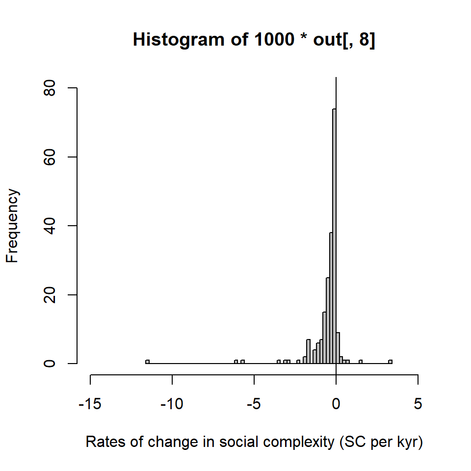

Here are results for the span of seven ceturies. Note the drop in DoF.

```r
print(t.test(out[,3], out[,2],paired=TRUE))
```

```
##
##  Paired t-test
##
## data:  out[, 3] and out[, 2]
## t = -4.6383, df = 81, p-value = 1.332e-05
## alternative hypothesis: true difference in means is not equal to 0
## 95 percent confidence interval:
##  -0.0012491734 -0.0004991778
## sample estimates:
## mean of the differences
##           -0.0008741756
```

And, finally, for century before and after acquiring MG. Here, we have only 12 NGAs, each with 2 data points to compare. Yes, there are only 11 DoF.

```r
print(t.test(out[,3], out[,2],paired=TRUE))
```

```
##
##  Paired t-test
##
## data:  out[, 3] and out[, 2]
## t = -1.8631, df = 11, p-value = 0.08935
## alternative hypothesis: true difference in means is not equal to 0
## 95 percent confidence interval:
##  -0.0045432205  0.0003777335
## sample estimates:
## mean of the differences
##            -0.002082744
```

## 1.5 Plotting Pre-Post MG

As in the main text, we will work mostly with the +/- 2000 years span as a baseline. First, let’s have a look at the variation in the rate of SC change over the 4000-year span of Whitehouse et al.’s data. Here, we are preparing the data set for a plot and proper analysis.

```r
out<-read.table("FullRates.csv", sep=",", header=TRUE)

out$Difference<-out[,3]-out[,2]

for(i in 2:length(out[,5])){
  out[i,8]<-out[i,5]-out[i-1,5]
}
out <-subset(out, out[,8]!=0) #getting rid of bug when the final row repeats in each NGA

write.csv(out, file="FullRates.csv",  row.names=FALSE)

out <-subset(out, out[,5]<2050) #Change this to modify time-window restriction from 700 years pre/post moralizing gods (<750) or # out to use full time-window


#?? Create stacked data set
out.s <- rbind(out,out)
out.s$Rate <- out.s$PostRate
out.s$prepost <- 1

out.s$Rate[1:length(out$PreRate)] <- out$PreRate
out.s$prepost[1:length(out$PreRate)] <- 0
out.s$prepost <- factor(out.s$prepost)

NGAs <- c("Deccan", "Kachi Plain", "Kansai", "Konya Plain", "Latium", "Middle Yellow River Valley", "Niger Inland Delta", "Orkhon Valley",  "Paris Basin", "Sogdiana", "Susiana", "Upper Egypt")

out.s <- out.s[out.s$NGA %in% NGAs,]
```

### 1.5.1 Scatter with regression line

Let’s plot the difference between pre-MG and post-MG SC change with confidence intervals

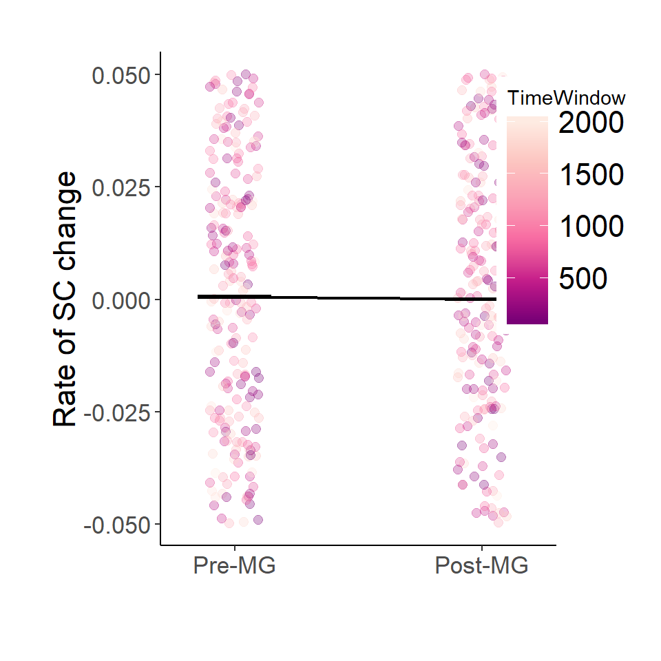

The reason why we cannot really see the Pre-/Post-MG difference is beacause the rate of SC change close to the supposed MG appearance is weighte more heavily BUT the clustering within NGAs is not accounted for - therefore, these heavily counted data points are all over the plot.

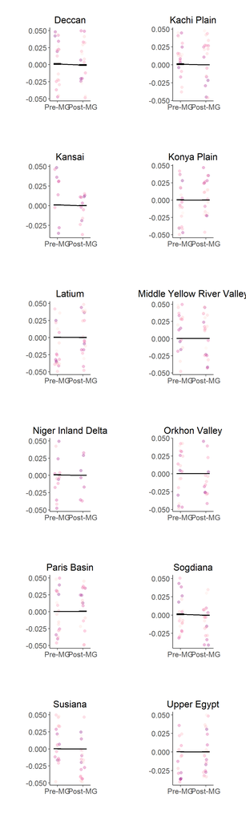

Looking at the scatter plots illustrates, how small the Pre-/Post-MG differences are. Let’s zoom-in on the difference between means.

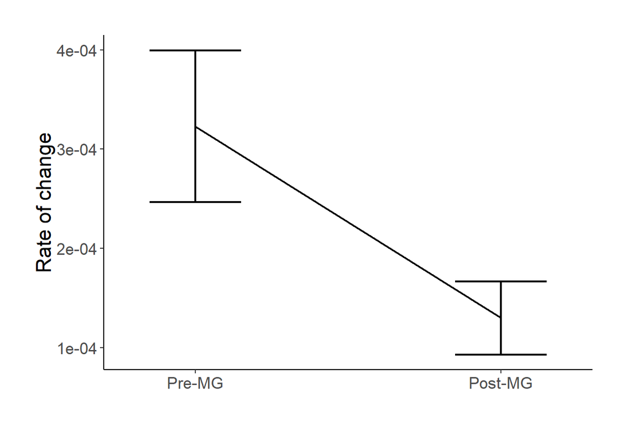

Well, as should be expected, the 95% CI are not overlapping, but the Y-axis scale show how small the differences in the rate of SC change are. This is beacause the data are corrected for time-lag by dividing the rate of SC change with the time-lag (it should be expected that the further the SC means are in time, the greater the difference).

### 1.5.2 Density plot

Let’s have one more look at a density plot of difference between Pre- and Post-MG.

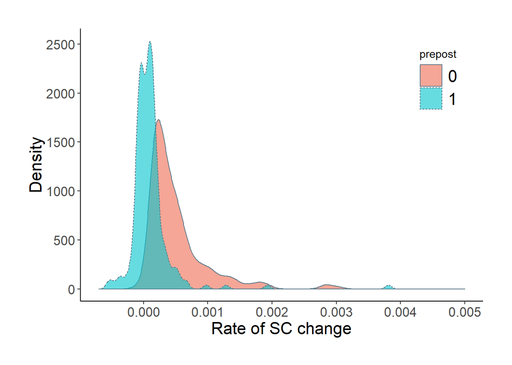

# 2. Forward-bias correction

## 2.1 Shift MG for t-100

```r
{
NGAs <- c("Deccan", "Kachi Plain", "Kansai", "Konya Plain", "Latium", "Middle Yellow River Valley", "Niger Inland Delta", "Orkhon Valley",  "Paris Basin", "Sogdiana", "Susiana", "Upper Egypt")


FB <- 100 ##? this is Forward Bias in years - we will subtract this number from MG appearence times. With increasing correction for FB (200, 300, 400), the positive difference grows...

out <- matrix(NA, nrow=0, ncol=7)
for(i in 1:length(NGAs)){
  dt <- dat[dat$NGA == NGAs[i],]
  MG<-subset(dt,MoralisingGods=="1")
  ##? This is my addition - we have to create a new subset MGAppear.FB, which will contain Mean SC for the time of MG's first appearance minus forward bias(FB)
  MGAppear<-subset(MG, Time==min(Time))
  t <- min(MG$Time)-FB
  MGAppear.FB<-subset(dt, Time==t)
##?
  for(j in 1: 100){
    Earliest<-subset(dt, Time==MGAppear.FB$Time-j*100)
    Latest<-subset(dt, Time==MGAppear.FB$Time+j*100)
    rates<-cbind(MGAppear$NGA,
                 ifelse(class(Earliest$Time)=="NULL","NA",
                        (MGAppear.FB$Mean-Earliest$Mean)/(MGAppear.FB$Time-Earliest$Time)),
                 ifelse(class(Latest$Time)=="NULL","NA",
                        ((Latest$Mean-MGAppear.FB$Mean)/(Latest$Time-MGAppear.FB$Time))),
                 (MGAppear.FB$End-MGAppear.FB$Start),
                 j*100,MGAppear$World.Region,
                 MGAppear$Family)
    out <- rbind(out,rates)
  }
  out <- rbind(out,rates) ##? This line is responsible for the "bug" described a few lines below
}
colnames(out)<-c("NGA","PreRate","PostRate","MGUncertainty","TimeWindow","Region", "Lang")

write.csv(out, file="FullRates.csv",  row.names=FALSE) #Exporting/importing to force it to read as numeric (there is probably a more elegant way to do this)

out<-read.table("FullRates.csv", sep=",", header=TRUE)

out$Difference<-out[,3]-out[,2]

##? save the difference into separate variable needed for histogram comparisons; note this variable automatically codes FB size
assign(paste0("d",FB),out$Difference*1000 )


for(i in 2:length(out[,5])){
  out[i,9]<-out[i,5]-out[i-1,5]}
out <-subset(out, out[,9]!=0) #getting rid of bug when the final row repeats in each NGA

write.csv(out, file="FullRates.csv",  row.names=FALSE)

out<-read.table("FullRates.csv", sep=",", header=TRUE)

out <-subset(out, out[,5]<2050) #Change this to modify time-window restriction from 700 years pre/post moralizing gods (<750) or 2050 out to use full time-window
write.csv(out, file="EqualRates.csv",  row.names=FALSE)


#?? Create stacked data set for a proper Pre-/Post-MG analysis
out.s <- rbind(out,out)
out.s$Rate <- out.s$PostRate
out.s$prepost <- 1

out.s$Rate[1:length(out$PreRate)] <- out$PreRate
out.s$prepost[1:length(out$PreRate)] <- 0
out.s$prepost <- factor(out.s$prepost)
NGAs <- c("Deccan", "Kachi Plain", "Kansai", "Konya Plain", "Latium", "Middle Yellow River Valley", "Niger Inland Delta", "Orkhon Valley",  "Paris Basin", "Sogdiana", "Susiana", "Upper Egypt")

out.s <- out.s[out.s$NGA %in% NGAs,]


}
```

Result for +/- 2000 years Pre/Post-MG with MG appearance shifted only 100 years back in time.

```r
print(t.test(out[,3], out[,2],paired=TRUE))
```

```
##
##  Paired t-test
##
## data:  out[, 3] and out[, 2]
## t = 3.9287, df = 199, p-value = 0.0001177
## alternative hypothesis: true difference in means is not equal to 0
## 95 percent confidence interval:
##  0.0001092693 0.0003295023
## sample estimates:
## mean of the differences
##            0.0002193858
```

This result shows that if we decrease each MG time by 100 years, MG positively predict SC! The result of Whitehouse et al. is dependent on the precision of MG appearance of only tens of years (on a scale of 1000s of years). That’s just plainly impossible.

Let’s plot the histogram with the rate of SC change:

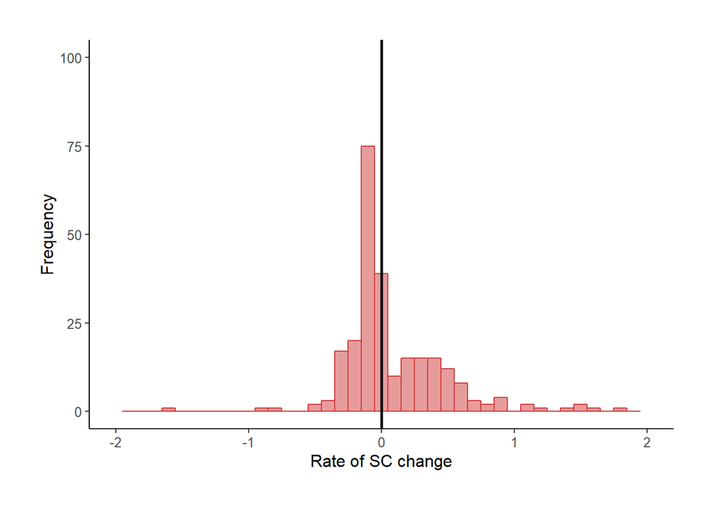

## 2.2 Density plot

Let’s look at the full density plot for both Pre- and Post-MG, so we can better see the difference.

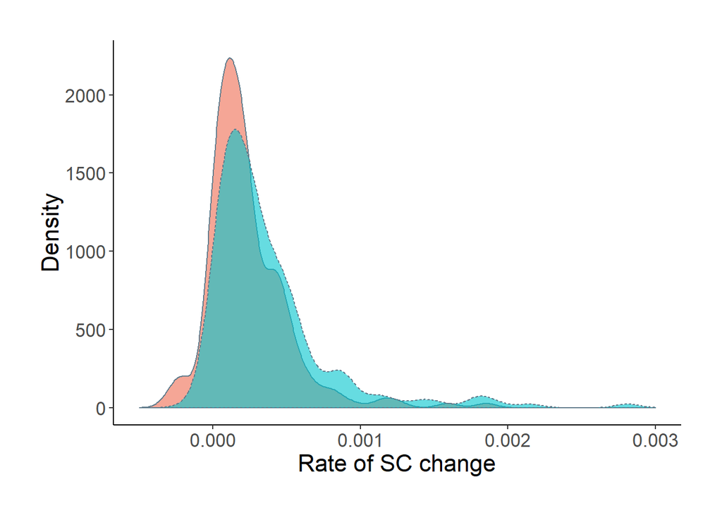

## 2.3 Corrected main plot

Here, we report the same plot as Whitehouse et al.’s Fig. 2a, only moving the supposed appearance of MG 100 years back.

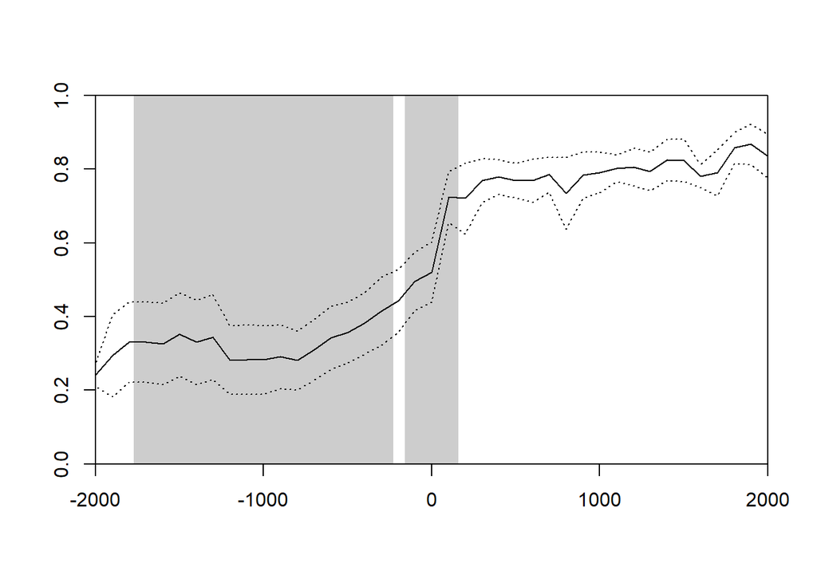

Moving MG appearance just 100 years back (the lowest time point possible, given the resolution of Whitehous et al. data), puts MGs directly into action!!

## 2.4 Corrected plot for all sites

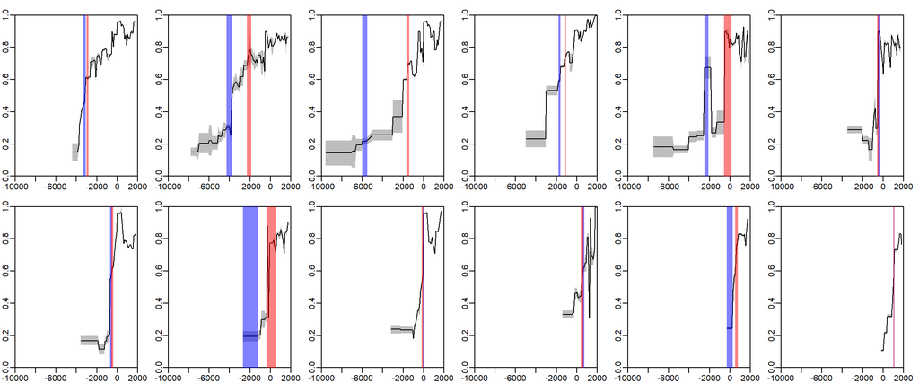

# 3. Hierarchical models

## 3.1. Load the original data again

```r
dat <- read.table("PC1_traj_merged.csv", sep=",", header=TRUE) #?? everything is here
dat$NGA<-as.character(dat$NGA)
NGAs <- levels(polities$NGA)
NGAs <- NGAs[NGAs != "Crete"]    #### Remove new NGAs
NGAs <- NGAs[NGAs != "Galilee"]

dat$World.Region <- as.factor(dat$World.Region)
dat$Family <- as.factor(dat$Family)

#?? I am going to add World.Region and language Family to this data set, so we can use it later in the models as nesting factors.

#Full time windows (up to 10,000 years before and after moralizing gods)
NGAs <- c("Big Island Hawaii", "Cambodian Basin", "Central Java", "Chuuk Islands", "Deccan",    "Ghanaian Coast", "Iceland", "Kachi Plain", "Kansai", "Kapuasi Basin",  "Konya Plain", "Latium", "Middle Yellow River Valley", "Niger Inland Delta", "Orkhon Valley",  "Paris Basin", "Sogdiana", "Susiana", "Upper Egypt","Yemeni Coastal Plain")

out <- matrix(NA, nrow=0, ncol=7)
for(i in 1:length(NGAs)){
  dt <- dat[dat$NGA == NGAs[i],]
  MG<-subset(dt,MoralisingGods=="1") #Replace "MoralisingGods" with "DoctrinalMode" or "Writing" to do these analyses
  #library(dplyr)
  #MG<-as.data.frame(MG %>% group_by(PolID) %>% sample_n(size = 1)) #randomly samples so there is only one century per polity
  MGAppear<-subset(MG, Time==min(Time))
  for(j in 1: 100){
    Earliest<-subset(dt, Time==MGAppear$Time-j*100)
    Latest<-subset(dt, Time==MGAppear$Time+j*100)
    rates <- cbind(MGAppear$NGA,
                   ifelse(class(Earliest$Time)=="NULL","NA",
                  (MGAppear$Mean-Earliest$Mean)/(MGAppear$Time-Earliest$Time)),
                  ifelse(class(Latest$Time)=="NULL","NA",
                  ((Latest$Mean-MGAppear$Mean)/(Latest$Time-MGAppear$Time))),
                  (MGAppear$End-MGAppear$Start),j*100,MGAppear$World.Region,MGAppear$Family)
    out <- rbind(out,rates)
  }
  out <- rbind(out,rates)
}
colnames(out)<-c("NGA","PreRate","PostRate","MGUncertainty","TimeWindow","Region", "Lang")

#mean(out$MGUncertainty) #Use this while replacing "MoralisingGods" as above to get uncertainty values for time-series

write.csv(out, file="FullRates.csv",  row.names=FALSE) #Exporting/importing to force it to read as numeric (there is probably a more elegant way to do this)
```

```r
out<-read.table("FullRates.csv", sep=",", header=TRUE)

out$Difference<-out[,3]-out[,2]

for(i in 2:length(out[,5])){
  out[i,8]<-out[i,5]-out[i-1,5]
}
out <-subset(out, out[,8]!=0) #getting rid of bug when the final row repeats in each NGA

write.csv(out, file="FullRates.csv",  row.names=FALSE)

out <-subset(out, out[,5]<2050) #Change this to modify time-window restriction from 700 years pre/post moralizing gods (<750) or # out to use full time-window


#?? Create stacked data set
out.s <- rbind(out,out)
out.s$Rate <- out.s$PostRate
out.s$prepost <- 1

out.s$Rate[1:length(out$PreRate)] <- out$PreRate
out.s$prepost[1:length(out$PreRate)] <- 0
out.s$prepost <- factor(out.s$prepost)

out.s$NGA <- as.factor(out.s$NGA)
out.s$Region <- as.factor(out.s$Region)
out.s$Lang <- as.factor(out.s$Lang)
```

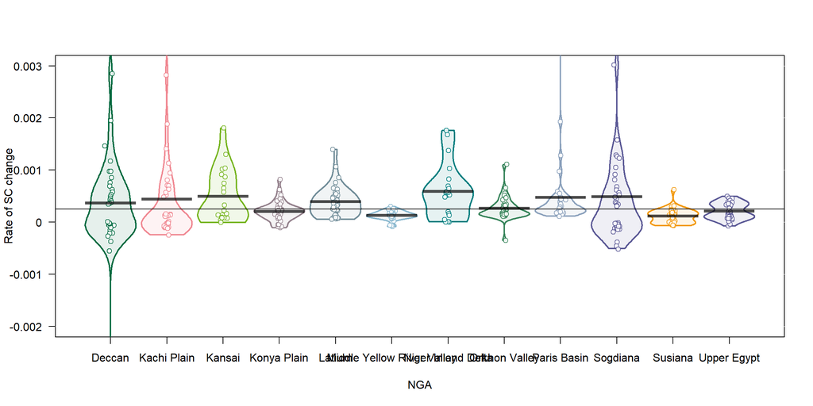

## 3.2. Linear models of rate of change

Starting with a straightforward linear model, we should first account for the nesting of time-points within NGAs, then the nesting of time-points within world regions, and finally let the pre-/post-MG effect vary by each NGA.

Note that here we work with the stacked data set (out.s) that was created in the previous chunk.

Note2: we also wanted to explore whether nesting within language families will have an effect, but the model gives a singular fit probably because region == language family for the 12 NGAs we have in the analysis. We could have also tried nesting of NGAs within world.regions, but the estimated interaction on varying intercepts would be probably very low and possibly cause convergence issues.

```r
summary(lm1 <- lmer(Rate ~ prepost + (1|NGA),data = out.s))

summary(lm2 <- lmer(Rate ~ prepost + (1|NGA) + (1|Region),data = out.s))

summary(lm3 <- lmer(Rate ~ prepost + (prepost|NGA) + (1|Region),data = out.s))
```

**Estimates with 95% CI**

|  | Rate | Rate | Rate |
| --- | --- | --- | --- |
|  | (1) | (2) | (3) |
| prepost1 | -0.001*** | -0.001*** | -0.001** |
|  | (-0.001, -0.0004) | (-0.001, -0.0004) | (-0.001, -0.0002) |
| Constant | 0.001*** | 0.001*** | 0.001*** |
|  | (0.0005, 0.001) | (0.0005, 0.001) | (0.0004, 0.001) |
| Observations | 424 | 424 | 424 |
| *Note:* | x p<.1; * p<.05; ** p<.01; *** p<.001 |  |  |

The Pre-/Post effects reported in Whitehouse et al. held up after accounting for the interdependencies among time-points. The nesting within NGAs and world regions did not explain much of the variability, but in combination with the varying effects of pre-post showed a minor influence.

Please keep in mind that the data are extremely problematic (see sections above) and here we are just trying to find an appropriate model for the data.

Let’s check the model fit.

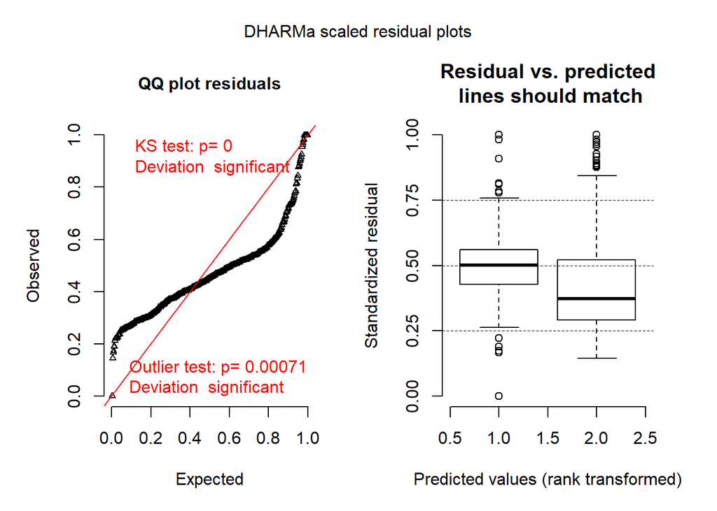

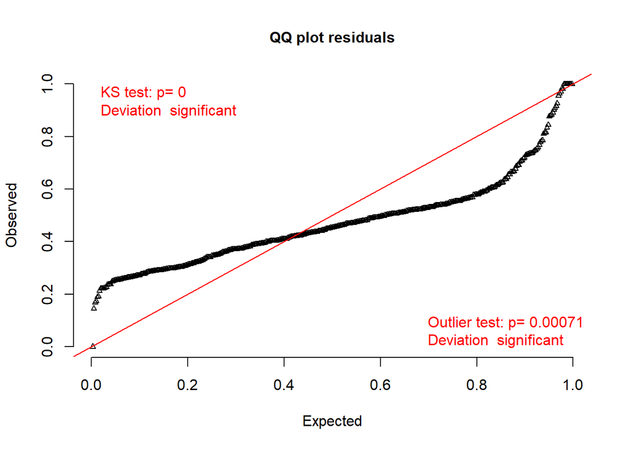

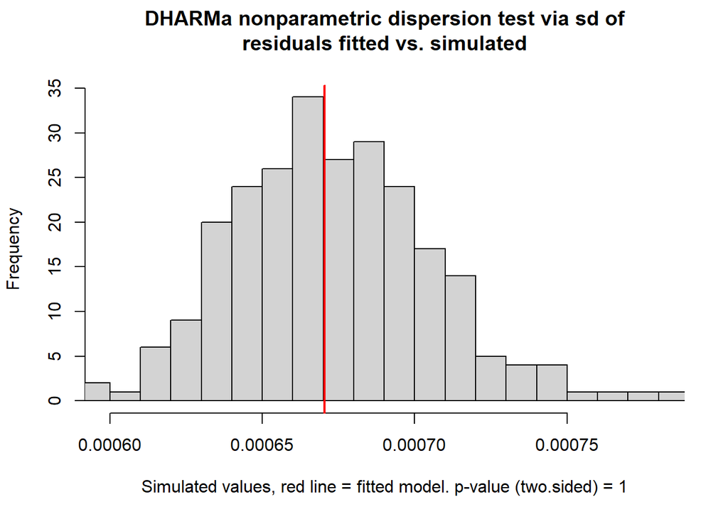

Normal distribution doesn’t look like an appropriate assumption here. This is probably caused by the fact that we are looking already at the rate of SC change rather than modeling SC at each time point with a proper hierarchical model. Let’s try to model just SC, not the computed rate of change with factorial MG variable. However, to do that, we have to commit the same fallacy (!!!) as the authors, i.e., treat MG == NA as MG == 0, otherwise there is nothing to model. So, with this gigantic caveat, let’s try to fit a proper growth model.

# 4. Social complexity growth model

First, let’s look at the SC distribution.

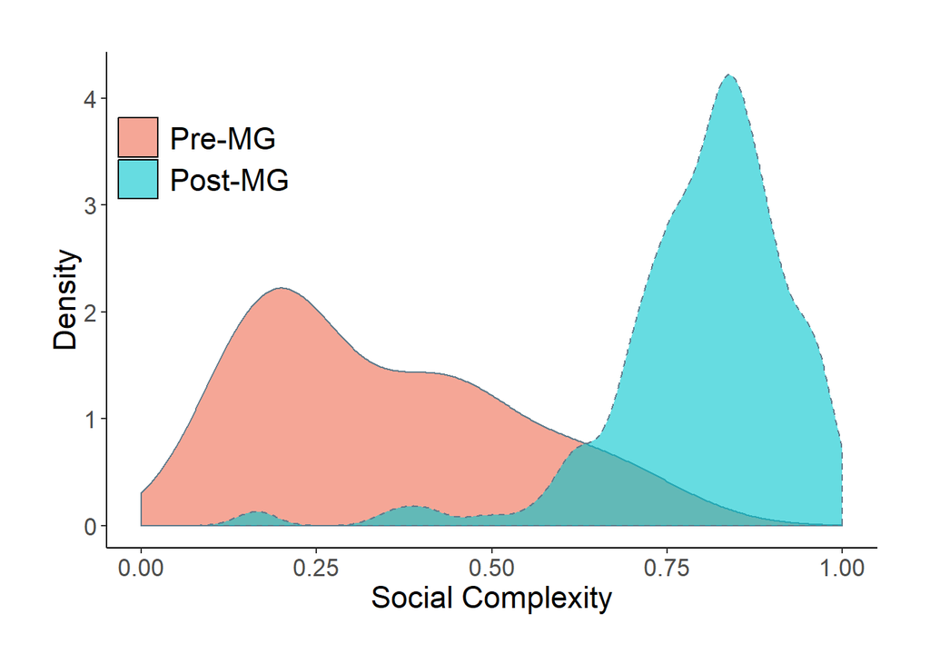

Even after accounting for the Pre-/Post-MG difference, the residuals will most likely not be normally distributed. Given how data were produced, the best option is to use beta regression, which is typically used for percentage data to account for the binding interval [0,1]. SC data are on the same interval.

## 4.1 +/- 700 years analysis

### 4.1.1. Prepare data

This is an important step. We have to take raw data and perform various transformations to accomodate for all the assumptions Whitehouse et al. made in their t-test analysis. Yes, we have to convert NAs to 0s. We also have to convert MG == 0 after the first MG detection to MG == 1 and a lot of other transformations, see below.

```r
##? first, select the 12 NGAs they work with
dat.MG <- dat
NGAs <- c("Deccan", "Kachi Plain", "Kansai", "Konya Plain", "Latium", "Middle Yellow River Valley", "Niger Inland Delta", "Orkhon Valley",  "Paris Basin", "Sogdiana", "Susiana", "Upper Egypt")
dat.MG <- dat.MG[dat$NGA %in% NGAs,]

##? agh, yes, do this! :(
dat.MG$MoralisingGods[is.na(dat.MG$MoralisingGods)] <- 0
dat.MG$MoralisingGods <- as.factor(dat.MG$MoralisingGods)


##? Standardize Time for each NGA to start with 0 (no matter whether the dates are BCE or CE)

for(i in 1:length(NGAs)){
  dt <- dat.MG[dat.MG$NGA == NGAs[i],]
  mt <- min(dt$Time)
  if(mt >= 0){
  dat.MG$Time[dat.MG$NGA == NGAs[i]] <- dat.MG$Time[dat.MG$NGA == NGAs[i]]-mt}
  else if(mt < 0){
  dat.MG$Time[dat.MG$NGA == NGAs[i]] <- dat.MG$Time[dat.MG$NGA == NGAs[i]]+abs(mt)
}
  }

dat.MG$NGA <- as.factor(dat.MG$NGA)

##?
### IMPORTANT! We have to censor the data to the +/- 700 years interval Pre- and Post-MG as in the original t-test analysis. We will also do the same later for the +/-2000 years as in the original paper

# Before doing that, however, we have to fix a mistake at the Deccan NGA - it misses one century (looks like a bug), so we have to recode the other centuries. Note that this problem will have to be fixed for more centuries, if we would like to run the +/- 2000 years analysis.

dat.MG$Time[dat.MG$NGA == "Deccan" & (dat.MG$Time == 3200)] <- 3100
dat.MG$Time[dat.MG$NGA == "Deccan" & (dat.MG$Time == 3300)] <- 3200

##? Ok, we can continue
censor = 750 ##? censor the data to +/- 7 centuries

for(i in 1:length(NGAs)){
  dt <- dat.MG[dat.MG$NGA == NGAs[i],]
  MG<-subset(dt,MoralisingGods=="1")
  MGAppear<-subset(MG, Time==min(Time))
  t <- MGAppear$Time
  t1 <- t-censor
  t2 <- t+censor
  if (min(dat.MG$Time[dat.MG$NGA == NGAs[i]], na.rm = T) < t1){
  dat.MG$Time[dat.MG$NGA == NGAs[i] & (dat.MG$Time < t1)] <- NA}
  if (max(dat.MG$Time[dat.MG$NGA == NGAs[i]], na.rm = T) > t2){
  dat.MG$Time[dat.MG$NGA == NGAs[i] & (dat.MG$Time > t2)] <- NA}
  }
dat.MG <- dat.MG[!is.na(dat.MG$Time),]

##? Make Time series at each NGA to start with 0 and end with 1400 (14 centuries of data = +/- 700 years)

for(i in 1:length(NGAs)){
  dt <- dat.MG[dat.MG$NGA == NGAs[i],]
  m <- max(dt$Time, na.rm=T)
  dat.MG$Time[dat.MG$NGA == NGAs[i]] <- dat.MG$Time[dat.MG$NGA == NGAs[i]] - m
  dat.MG$Time[dat.MG$NGA == NGAs[i]] <- dat.MG$Time[dat.MG$NGA == NGAs[i]] + 1400}

##? OK, now all sites acquire MG at year 700, so our data have 7 centuries before and 7 centuries after MG

##? Now, let's assume that MGs were present at all sites after their first detection (assumption of the t-test analysis presented in section 1.4)

dat.MG$MoralisingGods[dat.MG$Time>600] <- 1
```

### 4.1.2. Plot Pre/Post-MG

This plot is based on Whitehouse et al. raw data and nicely shows how unrealistic their approach is. Instead of drawing lines (as they did in Fig.2a), we used discrete data (data are sampled by centuries). That is, we didn’t connect the dots with artificial lines, just plotted mean data with standard errors for each century. The plot shows that before an NGA adopts MG, something curious happens that causes the NGA to immensely grow in social complexity within 100 years and obtain MG. This probably explains the bimodality we saw in the previous density plot. But keep in mind that these are just raw data, not taking into account the various nesting effects. We will explore those below.

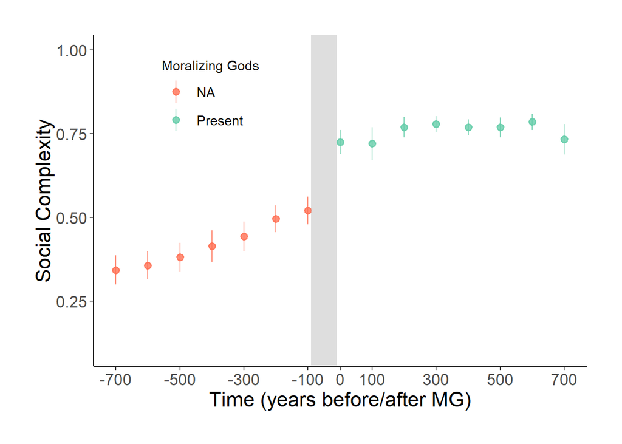

Let’s look also at the appearance of writing and whether it will correspond to the same sudden jump in SC.

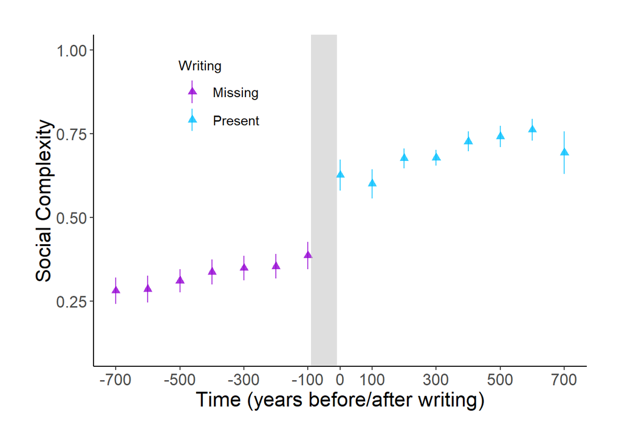

### 4.1.3. Compare beta with linear

As suggested above, the appropriate distributional assumption here should be the beta distribution. To compare the fit of gaussian and beta distributions, we will build a simple growth curve model where time will predict SC, and use AIC to compare guassian and beta assumpitons.

```r
##? First, let's compare gaussian and beta models

summary(lm1 <- glmmTMB(Mean ~ Time + (1|NGA), data = dat.MG, family = 'gaussian'))

summary(glm.b1 <- glmmTMB(Mean ~ Time + (1|NGA), data = dat.MG, family = 'beta'))
```

```r
a <- AICtab(lm1, glm.b1, sort = F)
t <- matrix(c(a$dAIC[1],a$dAIC[2],a$df[1],a$df[2]),ncol=2,byrow=F)
colnames(t) <- c("dAIC","df")
rownames(t) <- c("lm1","glm.b1")
kable(t)
```

|  | dAIC | df |
| --- | --- | --- |
| lm1 | 17.50561 | 4 |
| glm.b1 | 0.00000 | 4 |

The beta model seems to fit the data better. Let’s use the beta regression, then.

### 4.1.4. Beta models

This is the main multi-level growth curve analysis assuming a beta distribution of residuals. We fit three models, analogically to the hierarchical models presented in section 3 (see that section for the rationale of our modeling building procedure).

Note that it would be possible to also add a quadratic effect of time or to compare the shape of the growth curve (linear vs. quadratic) between conditions. However, this would venture too far beyond the original assumptions of Whitehouse et al.’s paper.

```r
summary(glm.b1 <- glmmadmb(Mean ~ Time*MoralisingGods + (1|NGA), data = dat.MG, family = 'beta'))

summary(glm.b2 <- glmmadmb(Mean ~ Time*MoralisingGods + (1|NGA) + (1|World.Region), data = dat.MG, family = 'beta'))

summary(glm.b3 <- glmmadmb(Mean ~ Time*MoralisingGods + (Time|NGA) + (1|World.Region), data = dat.MG, family = 'beta'))

xtract.cof("glm.b",c(1:3),"","glmmadmb",3)
##? Define list of coefficients extracted from glmmTMB models: estimates, confidence intervals, and p-values
E.vector <- list(Mods[[1]][,1],Mods[[2]][,1],Mods[[3]][,1])
CI.vector <- list(Mods[[1]][,2:3],Mods[[2]][,2:3],Mods[[3]][,2:3])
p.vector <- list(Mods[[1]][,4],Mods[[2]][,4],Mods[[3]][,4])
```

```r
a <- AICtab(glm.b3,glm.b2,glm.b1, sort = F)
t <- matrix(c(a$dAIC[1],a$dAIC[2],a$dAIC[3],a$df[1],a$df[2],a$df[3]),ncol=2,byrow=F)
colnames(t) <- c("dAIC","df")
rownames(t) <- c("glm.b3","glm.b2","glm.b1")
kable(t)
```

|  | dAIC | df |
| --- | --- | --- |
| glm.b3 | 0.000 | 8 |
| glm.b2 | 41.202 | 7 |
| glm.b1 | 39.202 | 6 |

The third model fits data best.

**Estimates with 95/ CI for Social Complexity. Estimates from beta regression are logit-transformed**

|  | (1) | (2) | (3) |
| --- | --- | --- | --- |
| Time | 0.00032*** | 0.00032*** | 0.00034*** |
|  | (0.00017, 0.00046) | (0.00017, 0.00046) | (0.00017, 0.00050) |
| MoralisingGods1 | 0.33428*** | 0.33428*** | 0.33893*** |
|  | (0.23091, 0.40320) | (0.23091, 0.40320) | (0.26154, 0.39467) |
| Time:MoralisingGods1 | -0.00026** | -0.00026** | -0.00027*** |
|  | (-0.00046, -0.00006) | (-0.00046, -0.00006) | (-0.00043, -0.00011) |
| Constant | 0.33182*** | 0.33182*** | 0.32398*** |
|  | (0.28083, 0.38708) | (0.28082, 0.38709) | (0.23780, 0.42401) |
| Observations | 179 | 179 | 179 |
| *Note:* | x p<.1; * p<.05; ** p<.01; *** p<.001 |  |  |

Let’s explore goodness-of-fit measures.

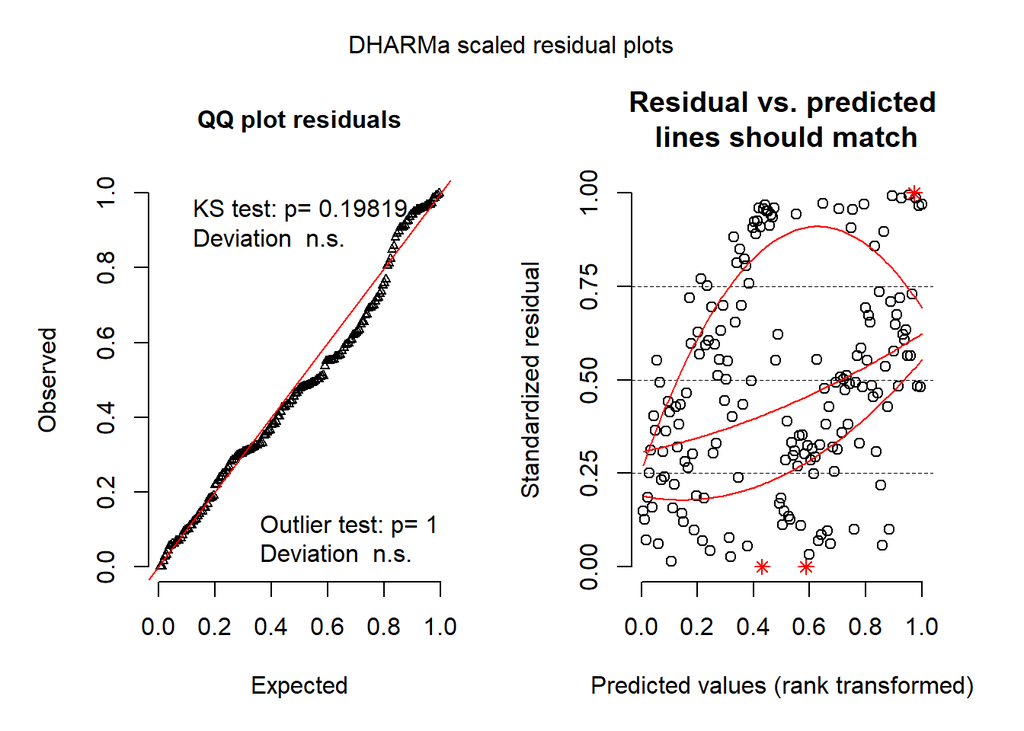

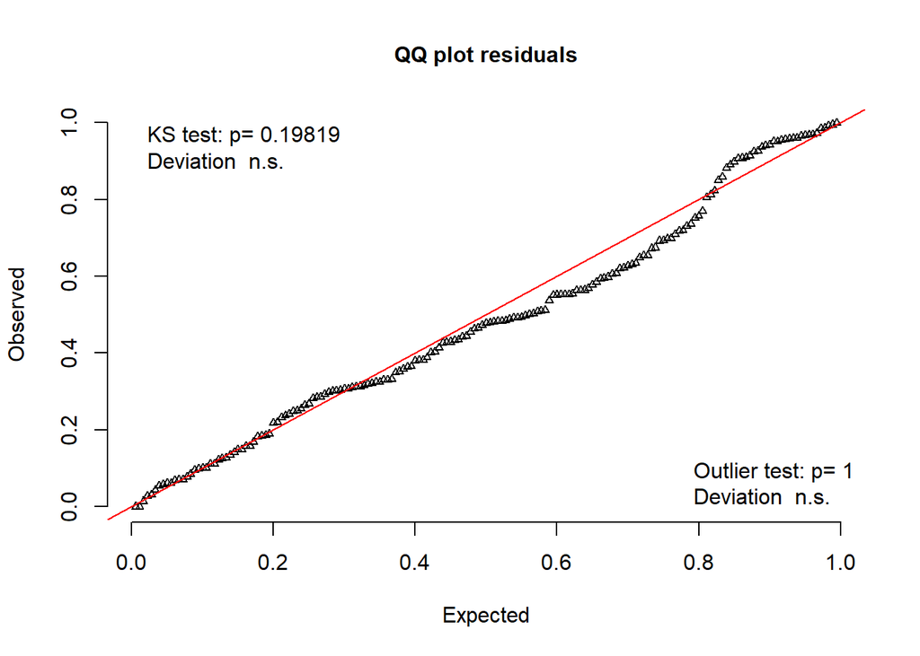

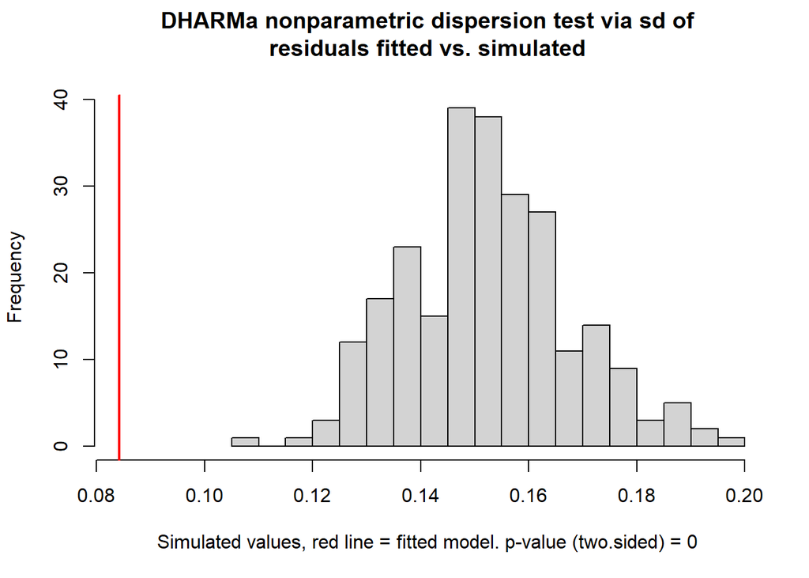

The glm.b3 model appears to be a pretty good fit based on the DHARMa estimation, although we are still missing something and the data seem to be underdispersed (note that DHARMa can’t yet handle random effects in GLMM in the residual vs. predicted plot).

### 4.1.5. Predicted values plot

These are predicted growth curves from a linear plot.

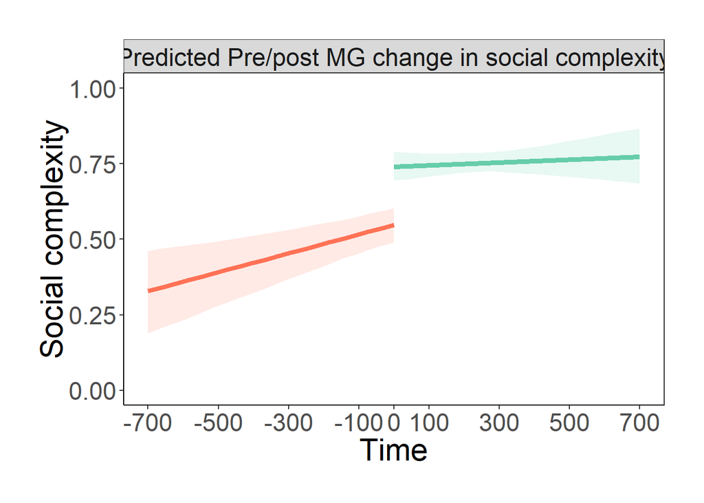

## 4.2 +/- 2000 years analysis

We are repeating the same model-building procedure as in 4.1, only for the more extensive data set. There are some minor changes in the code to accomodate for the time-frame difference.

### 4.2.1. Prepare data

```r
##? first, select the 12 NGAs they work with
{dat.MG <- dat
NGAs <- c("Deccan", "Kachi Plain", "Kansai", "Konya Plain", "Latium", "Middle Yellow River Valley", "Niger Inland Delta", "Orkhon Valley",  "Paris Basin", "Sogdiana", "Susiana", "Upper Egypt")
dat.MG <- dat.MG[dat$NGA %in% NGAs,]

# agh, yes, do this! :(
dat.MG$MoralisingGods[is.na(dat.MG$MoralisingGods)] <- 0
dat.MG$MoralisingGods <- as.factor(dat.MG$MoralisingGods)


##? Standardize Time for each NGA

for(i in 1:length(NGAs)){
  dt <- dat.MG[dat.MG$NGA == NGAs[i],]
  mt <- min(dt$Time)
  if(mt >= 0){
  dat.MG$Time[dat.MG$NGA == NGAs[i]] <- dat.MG$Time[dat.MG$NGA == NGAs[i]]-mt}
  else if(mt < 0){
  dat.MG$Time[dat.MG$NGA == NGAs[i]] <- dat.MG$Time[dat.MG$NGA == NGAs[i]]+abs(mt)
}
  }


##?
### IMPORTANT! We have to censor the data to the +/- 700 years interval Pre- and Post-MG as in the original t-test analysis. We can also do for 2000 years as in the original paper

# Before doing that, however, we have to fix a mistake at the Deccan NGA - it misses one century (looks like a bug), so we have to recode the other centuries. Note that this problem will have to be fixed with different numbers, if we would like to run the +/- 2000 years analysis.

dat.MG$Time[dat.MG$NGA == "Deccan" & (dat.MG$Time > 3000)] <- dat.MG$Time[dat.MG$NGA == "Deccan" & (dat.MG$Time > 3000)] - 100

##? Ok, we can continue
censor = 2050

for(i in 1:length(NGAs)){
  dt <- dat.MG[dat.MG$NGA == NGAs[i],]
  MG<-subset(dt,MoralisingGods=="1")
  MGAppear<-subset(MG, Time==min(Time))
  t <- MGAppear$Time
  t1 <- t-censor
  t2 <- t+censor
  if (min(dat.MG$Time[dat.MG$NGA == NGAs[i]], na.rm = T) < t1){
  dat.MG$Time[dat.MG$NGA == NGAs[i] & (dat.MG$Time < t1)] <- NA}
  if (max(dat.MG$Time[dat.MG$NGA == NGAs[i]], na.rm = T) > t2){
  dat.MG$Time[dat.MG$NGA == NGAs[i] & (dat.MG$Time > t2)] <- NA}
  }
dat.MG <- dat.MG[!is.na(dat.MG$Time),]

##? Make Time series at each NGA to start with 0
for(i in 1:length(NGAs)){
  dt <- dat.MG[dat.MG$NGA == NGAs[i],]
  m <- max(dt$Time, na.rm=T)
  dat.MG$Time[dat.MG$NGA == NGAs[i]] <- dat.MG$Time[dat.MG$NGA == NGAs[i]] - m
  dt <- dat.MG[dat.MG$NGA == NGAs[i],]
  m <- min(dt$Time, na.rm=T)
  dat.MG$Time[dat.MG$NGA == NGAs[i]] <- dat.MG$Time[dat.MG$NGA == NGAs[i]] + abs(m)}
##? note that the last line adding + 1400 would have to be changed to + 4000 for the +/- 2000 analysis

##? We have to impute new rows now, so each NGA would have MG == 1 at Time == 2000

# Deccan
New <- dat.MG[1,]
New[,] <- NA
dat.1 <- dat.MG[1:39,]
dat.2 <- dat.MG[40:nrow(dat.MG),]
dat.MG <- rbind(dat.1, New, dat.2)
dat.MG[40,1] <- dat.MG[39,1]
dat.MG[40,4] <- dat.MG[39,4] + 100

# Kansai
New <- dat.MG[1:11,]
New[1:11,] <- NA
dat.1 <- dat.MG[1:81,]
dat.2 <- dat.MG[82:nrow(dat.MG),]
dat.MG <- rbind(dat.1, New, dat.2)
dat.MG[82:92,1] <- dat.2[1,1]

New <- dat.MG[1:8,]
New[1:8,] <- NA
dat.1 <- dat.MG[1:114,]
dat.2 <- dat.MG[115:nrow(dat.MG),]
dat.MG <- rbind(dat.1, New, dat.2)
dat.MG[115:122,1] <- dat.1[114,1]

dat.MG$Time[dat.MG$NGA=="Kansai"] <- seq(0,4000,100)


# Niger Inland Delta
New <- dat.MG[1:7,]
New[1:7,] <- NA
dat.1 <- dat.MG[1:245,]
dat.2 <- dat.MG[246:nrow(dat.MG),]
dat.MG <- rbind(dat.1, New, dat.2)
dat.MG[246:273,1] <- dat.2[1,1]


New <- dat.MG[1:13,]
New[1:13,] <- NA
dat.1 <- dat.MG[1:273,]
dat.2 <- dat.MG[274:nrow(dat.MG),]
dat.MG <- rbind(dat.1, New, dat.2)
dat.MG[274:286,1] <- dat.1[273,1]

dat.MG$Time[dat.MG$NGA=="Niger Inland Delta"] <- seq(0,4000,100)

#Orkhon Valley

New <- dat.MG[1,]
New[,] <- NA
dat.1 <- dat.MG[1:286,]
dat.2 <- dat.MG[287:nrow(dat.MG),]
dat.MG <- rbind(dat.1, New, dat.2)
dat.MG[287,1] <- dat.MG[288,1]
dat.MG[287,4] <- 0


New <- dat.MG[1:6,]
New[1:6,] <- NA
dat.1 <- dat.MG[1:321,]
dat.2 <- dat.MG[322:nrow(dat.MG),]
dat.MG <- rbind(dat.1, New, dat.2)
dat.MG[322:327,1] <- dat.1[320,1]

dat.MG$Time[dat.MG$NGA=="Orkhon Valley"] <- seq(0,4000,100)

# Paris Basin
New <- dat.MG[1:2,]
New[1:2,] <- NA
dat.1 <- dat.MG[1:365,]
dat.2 <- dat.MG[366:nrow(dat.MG),]
dat.MG <- rbind(dat.1, New, dat.2)
dat.MG[366:367,1] <- dat.1[365,1]
dat.MG[366,4] <- 3900
dat.MG[367,4] <- 4000

# Upper Egypt
New <- dat.MG[1:5,]
New[1:5,] <- NA
dat.1 <- dat.MG[1:449,]
dat.2 <- dat.MG[450:nrow(dat.MG),]
dat.MG <- rbind(dat.1, New, dat.2)
dat.MG[450:454,1] <- dat.2[1,1]

dat.MG$Time[dat.MG$NGA=="Upper Egypt"] <- seq(0,4000,100)

}


##?OK, now all sites acquire MG at year 2000, so our data have 20 centuries before and 20 centuries after MG, although we miss data for some sites for which there are not so long records. This should be taken care of in our multi-level models, though.

##? Now, let's assume that MGs were present at all sites after first detection (assumption of the t-test analysis presented in section 1.4)

dat.MG$MoralisingGods[dat.MG$Time>1900] <- 1

dat.MG$NGA <- as.factor(dat.MG$NGA)
```

### 4.2.2. Plot Pre/Post-MG

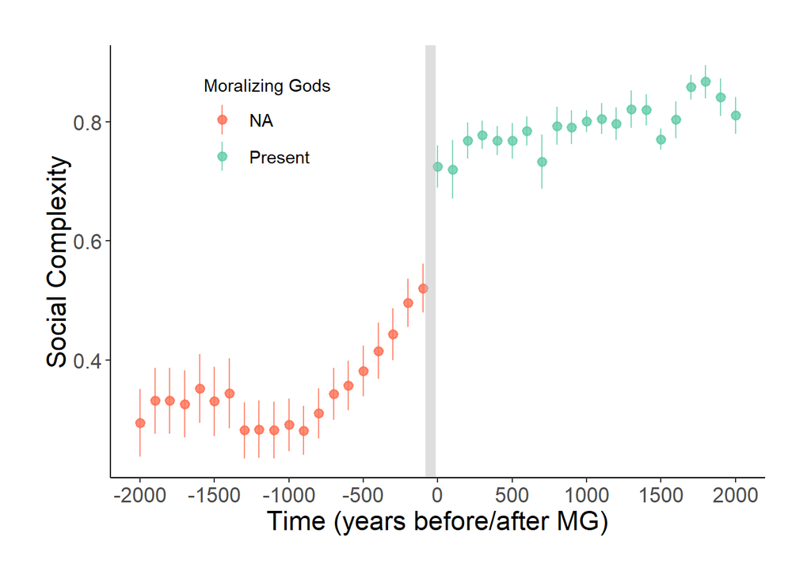

### 4.2.3. Compare beta with linear

```r
##? First, let's compare gaussian and beta models
dat.MGn <- na.omit(subset(dat.MG, select = c(Mean, Time, NGA)))

summary(lm1 <- glmmTMB(Mean ~ Time + (1|NGA), data = dat.MGn, family = 'gaussian'))

summary(glm.b1 <- glmmTMB(Mean ~ Time + (1|NGA), data = dat.MGn, family = 'beta'))
```

```r
a <- AICtab(lm1, glm.b1, sort = F)
t <- matrix(c(a$dAIC[1],a$dAIC[2],a$df[1],a$df[2]),ncol=2,byrow=F)
colnames(t) <- c("dAIC","df")
rownames(t) <- c("lm1","glm.b1")
kable(t)
```

|  | dAIC | df |
| --- | --- | --- |
| lm1 | 81.3646 | 4 |
| glm.b1 | 0.0000 | 4 |

### 4.2.4. Beta models

```r
dat.MG1 <- na.omit(subset(dat.MG, select = c(Mean, Time, MoralisingGods, NGA, World.Region)))

summary(glm.b1 <- glmmadmb(Mean ~ Time*MoralisingGods + (1|NGA), data = dat.MG1, family = 'beta'))

summary(glm.b2 <- glmmadmb(Mean ~ Time*MoralisingGods + (1|NGA) + (1|World.Region), data = dat.MG1, family = 'beta'))

summary(glm.b3 <- glmmadmb(Mean ~ Time*MoralisingGods + (Time|NGA) + (1|World.Region), data = dat.MG1, family = 'beta'))

xtract.cof("glm.b",c(1:3),"","glmmadmb",3)
##? Define list of coefficients extracted from glmmTMB models: estimates, confidence intervals, and p-values
E.vector <- list(Mods[[1]][,1],Mods[[2]][,1],Mods[[3]][,1])
CI.vector <- list(Mods[[1]][,2:3],Mods[[2]][,2:3],Mods[[3]][,2:3])
p.vector <- list(Mods[[1]][,4],Mods[[2]][,4],Mods[[3]][,4])
```

```r
a <- AICtab(glm.b3,glm.b2,glm.b1, sort = F)
t <- matrix(c(a$dAIC[1],a$dAIC[2],a$dAIC[3],a$df[1],a$df[2],a$df[3]),ncol=2,byrow=F)
colnames(t) <- c("dAIC","df")
rownames(t) <- c("glm.b3","glm.b2","glm.b1")
kable(t)
```

|  | dAIC | df |
| --- | --- | --- |
| glm.b3 | 0.000 | 8 |
| glm.b2 | 30.594 | 7 |
| glm.b1 | 28.624 | 6 |

**Estimates with 95/ CI for Social Complexity. Estimates from beta regression are logit-transformed**

|  | (1) | (2) | (3) |
| --- | --- | --- | --- |
| Time | 0.00010*** | 0.00010*** | 0.00012*** |
|  | (0.00007, 0.00014) | (0.00007, 0.00014) | (0.00008, 0.00017) |
| MoralisingGods1 | 0.32885*** | 0.32886*** | 0.31791*** |
|  | (0.25380, 0.38453) | (0.25383, 0.38453) | (0.24439, 0.37386) |
| Time:MoralisingGods1 | -0.00003 | -0.00003 | -0.00003 |
|  | (-0.00008, 0.00002) | (-0.00008, 0.00002) | (-0.00008, 0.00002) |
| Constant | 0.26030*** | 0.26035*** | 0.23766*** |
|  | (0.21869, 0.30673) | (0.21792, 0.30780) | (0.17416, 0.31548) |
| Observations | 436 | 436 | 436 |
| *Note:* | x p<.1; * p<.05; ** p<.01; *** p<.001 |  |  |

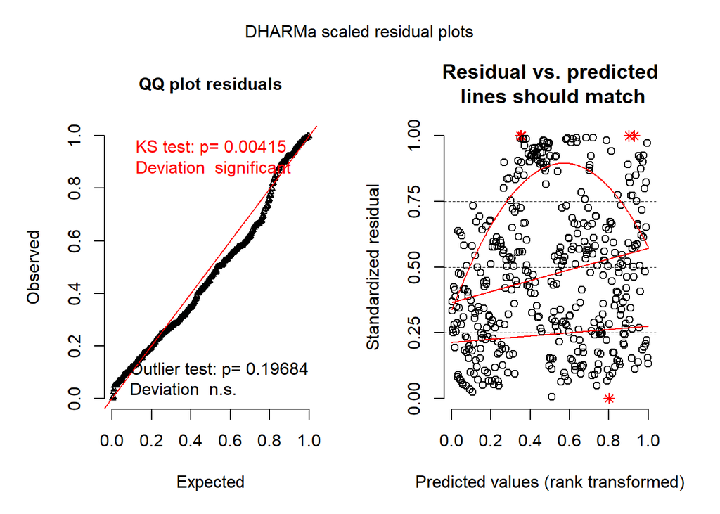

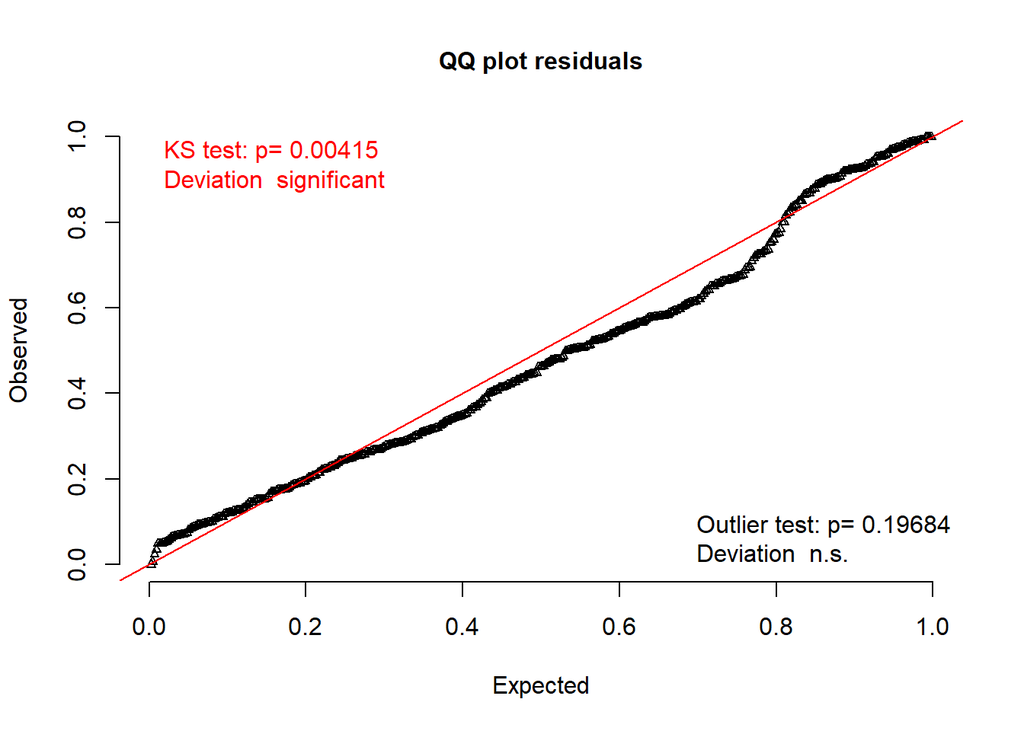

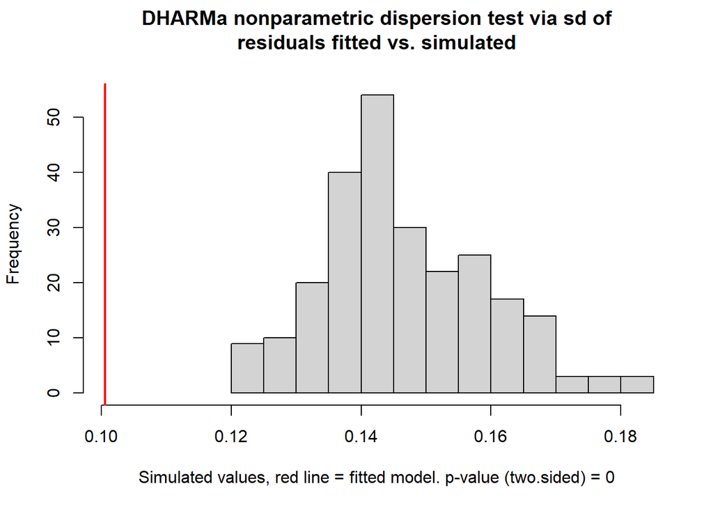

### 4.2.5. Predicted values plot

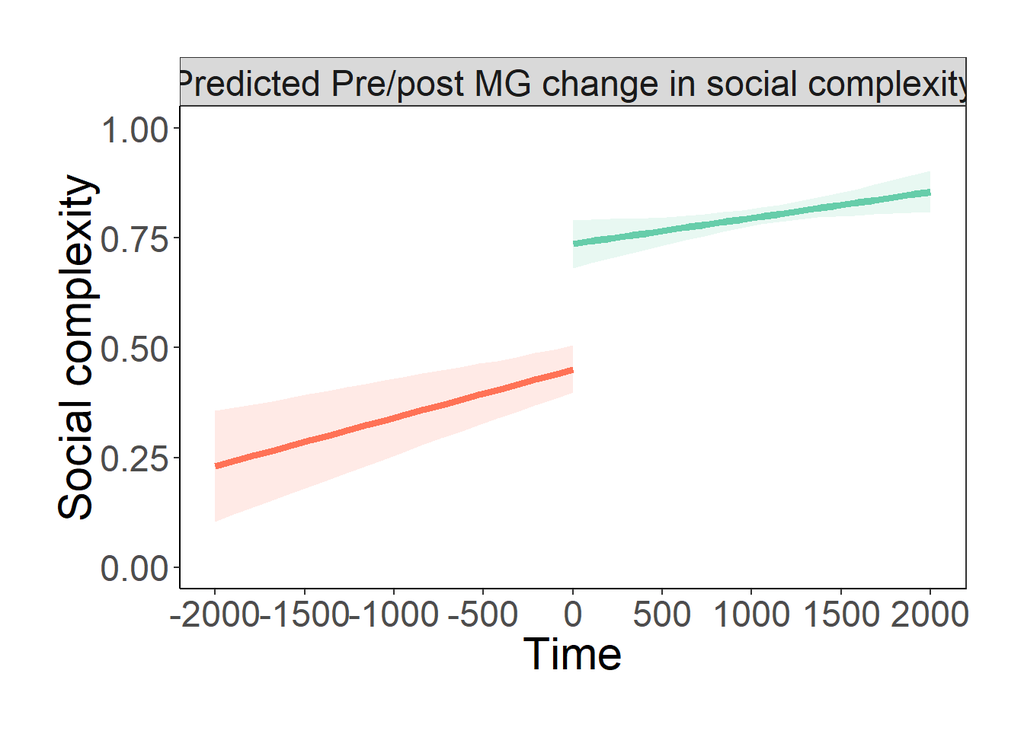

# 5. Summary

The main point of this document was to show how problematic the assumption and statistical approach of Whitehouse et al. are. The most serious problem is the assumption that at each NGA, we could detect MG within decades after their first appearance. This is, of course, impossible and if anything can be concluded from the data that Whitehouse et al. present is the exact opposite of what they claim - i.e., MGs precede social complexity growth!

Regarding Whitehouse et al.’s statistical approach, they did not take into account various nestings presented in their data (violation of the data independece assumption) and the fact that residuals of social complexity (or residuals of the rate of SC change, for that matter) are not normally distributed. We attempted to account for both violations by using generalized linear mixed models, which allowed us to control for the nesting within data, fit individul time effects for each NGA, and account for the non-normality of residuals. We believe that the final models present much more appropriate and trustworthy estimates, although still estimates based on very problematic data.